# hdWGCNA of Mesoderm Data

This notebook is for running hdWGCNA (single-cell WGCNA) and follows the tutorial here: https://smorabit.github.io/hdWGCNA/articles/basic_tutorial.html. Because Stephen already preprocessed (normalized) the data, we can read in both the raw and normalized data into a Seurat object, as well as the UMAP calculated. We also read in the metadata to add cell population labels and the embryo labels to the seurat object.

# Setup

```r
# # install BiocManager
# install.packages("BiocManager")
#
# # install Bioconductor core packages
# BiocManager::install()
#
# # install additional packages:
# install.packages(c("Seurat", "WGCNA", "igraph", "devtools"))
# install.packages('harmony')
# devtools::install_github('smorabit/hdWGCNA', ref='dev')

# single-cell analysis package
library(Seurat)

# plotting and data science packages
library(tidyverse)
library(cowplot)
library(patchwork)
library(harmony)
# co-expression network analysis packages:
library(WGCNA)
library(hdWGCNA)

# using the cowplot theme for ggplot
theme_set(theme_cowplot())

# set random seed for reproducibility
set.seed(12345)
```

## Read in data

```r
raw_counts <- read.table(
  file = './data/raw-counts-mesoderm-wildtype.csv',row.names = 1, header  = 1, sep = ','
)
normalized_data <- read.table(
  file = './data/log1p-normalized-counts-mesoderm-wildtype.csv', row.names = 1, header = 1, sep = ','
)
seurat<-CreateSeuratObject(counts = raw_counts, min.cells = 3, min.genes = 350, project = "mesoderm")
```

## Load metadata and add to seurat object

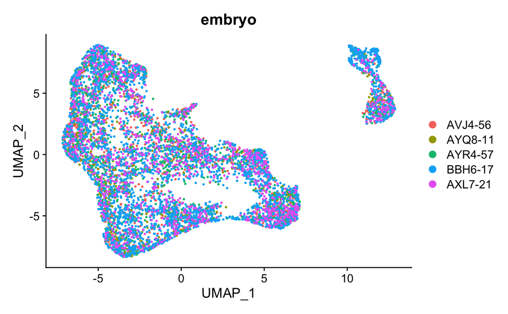

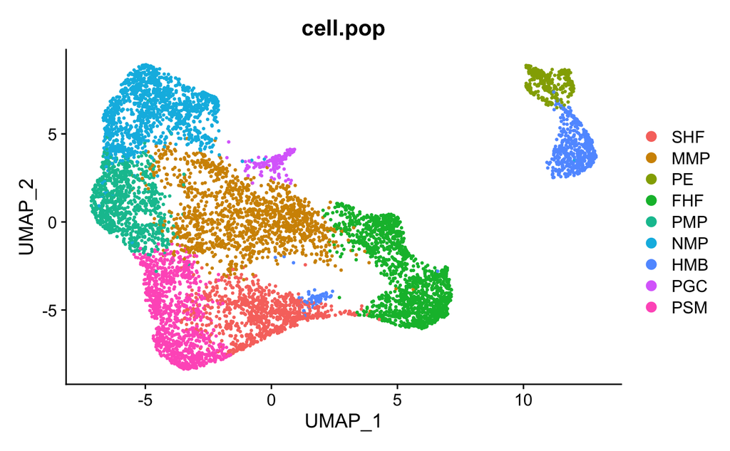

## Prepare for hgWGCNA

As per the tutorial, our seurat object needs to first run through the following Seurat steps:

- Normalize the gene expression matrix NormalizeData.
- Identify highly variable genes VariableFeatures.
- Scale the normalized expression data ScaleData
- Perform dimensionality reduction RunPCA and batch correction if needed RunHarmony.
- Non-linear dimensionality reduction RunUMAP for visualizations.
- Group cells into clusters (FindNeighbors and FindClusters).

We already have the normalization and the UMAP. We perform the other steps below.

```r
seurat <- FindVariableFeatures(seurat, selection.method = "vst", nfeatures = 2000)
# Identify the 10 most highly variable genes
top10 <- head(VariableFeatures(seurat), 10)

# plot variable features with and without labels
plot1 <- VariableFeaturePlot(seurat)
plot2 <- LabelPoints(plot = plot1, points = top10, repel = TRUE)
```

```
When using repel, set xnudge and ynudge to 0 for optimal results
```

[figure not shown]

```r
plot2
```

```r
all.genes <- rownames(seurat)
seurat <- ScaleData(seurat, features = all.genes)
seurat <- RunPCA(seurat, features = VariableFeatures(object = seurat))
```

```
PC_ 1
Positive:  Pou5f1, Rbp1, Fst, T, Hoxb1, Cdx1, Sp5, Gal, Tbx6, Hes7
       Frzb, Tcea3, Gbx2, Tspan13, Ldhb, Bcat1, Meis2, Dll1, Foxb1, Grsf1
       Fgf8, Dll3, Mixl1, Cdkn1a, Hoxa1, Wnt3a, Aldh1a2, Apln, Ddit4, Crabp2
Negative:  H19, Mest, Krt8, Krt18, Polg, Car4, Stard8, Ppic, Pmp22, Podxl
       Slc25a4, Dok4, Ahnak, Tmem88, Sparc, Clic1, Prdm6, Tspan4, Nrp1, Csrp2
       Spin2c, Cnn2, Hsd11b2, Hand1, Serpinh1, Tbx20, Smtnl2, Bmp4, Fth1, Srm
PC_ 2
Positive:  Oaz1, Ftl1, Hmgn1, mt-Atp6, mt-Co1, mt-Co2, mt-Nd4, Tmsb10, mt-Nd1, mt-Cytb
       Dynll1, Pfn1, Tma7, Lsm4, mt-Co3, D8Ertd738e, Selenow, Hmgn2, Marcksl1, Bex3
       mt-Nd2, H2afv, Atp5g1, Gng5, Serf2, Prtg, Zfp706, Luzp1, H2afz, Rps27l
Negative:  Hspa8, Atp5b, Npm1, Cct5, Cct8, Hsp90aa1, Cct4, Tuba1b, Cct7, Gapdh
       Impdh2, Slc25a3, Eef1a1, Hspd1, Cct3, Pkm, Eif3m, Eif4a1, Slc25a5, Eif3e
       Ldha, Ppia, Dnaja1, Atp5a1, Pa2g4, Tubb4b, Hsp90ab1, Tubb5, Magoh, Tcp1
PC_ 3
Positive:  Tceal9, Hand1, Peg3, Spin2c, Msx2, Msx1, Phlda2, Csrp2, Foxf1, Meg3
       Dlk1, Bmp4, Pmp22, Krt18, Rbbp7, Tuba1a, Bex3, Krt8, Lrpap1, Slc9a3r1
       Tmem88, Basp1, Cfc1, Cdx2, Rtn4, Gpc3, Vim, Slc2a1, Arl4c, Tpm1
Negative:  Cited4, Gata1, Lmo2, Tal1, Nrip3, Gfi1b, Runx1, Gypc, Fam212a, Hhex
       Fli1, Rasgrp2, Hbb-bh1, Rnd2, Cbfa2t3, Snca, Ikzf1, Gata2, Tspan32, Slc32a1
       Rbm38, Car2, Ubash3b, Klf1, F2r, Lyl1, Scube2, Itga2b, Prkar2b, Reln
PC_ 4
Positive:  Sfrp1, Irx1, Irx5, Tcf15, Foxc2, Ppp1r1a, Ifitm1, Crabp1, Hmga2, Otx2
       Emb, Cer1, Myl7, Alx1, Adrb3, Dusp9, Laptm4b, Epb41l3, Twist1, Nnat
       Mn1, Irx3, Prrx2, Col23a1, Sms, Tbx1, Foxc1, Rasgrp3, Lrig3, Meis1
Negative:  Bex1, Bex4, Cdx2, Crip2, Nkx1-2, Cdx1, Meg3, Grsf1, T, Wfdc2
       Slc2a3, Nefm, Apela, Apln, Mixl1, Wnt3a, Ccnd2, Rasgrp2, Cdh1, Spint2
       Oat, Hoxb4, Syngr2, Wnt5b, Fgf17, Fgf3, Epcam, Ezr, Cdc42ep5, Tspan13
PC_ 5
Positive:  Rps17, Rpl37a, Rps12, Rps28, Rps15a, Rpl41, Rplp2, Rpl36, Xist, Rps21
       Rpl37, Rpl35a, Rps27, Rpl39, Rplp1, Rpl38, Rps29, Ezr, Rpl27, Slc2a1
       Gm26917, Rpl30, Cox7c, Igfbp2, Rpl36al, Rps27rt, Pim2, Tmsb4x, AC160336.1, Basp1
Negative:  Cdx4, Phlda2, Mesp1, Fn1, Id1, Hoxd9, Rspo3, H3f3b, Pfn1, Cited1
       Ubb, Smc6, Isl1, Sct, Rftn1, Ifitm1, Psme2, Igfbp4, Bambi, Marcksl1
       Laptm4b, Amot, Zfand6, Efna1, Ifitm2, Prdx1, Tgfb1, Mogat2, Fgf3, Crabp1
```

```r
seurat <- FindNeighbors(seurat, dims = 1:10)
seurat <- FindClusters(seurat, resolution = 0.5)
```

```
Modularity Optimizer version 1.3.0 by Ludo Waltman and Nees Jan van Eck

Number of nodes: 7936
Number of edges: 236614

Running Louvain algorithm...
```

```
Maximum modularity in 10 random starts: 0.8952
Number of communities: 13
Elapsed time: 0 seconds
```

## Setup WGCNA

We define how hdWGCNA will be run, and the name of the experiment.

```r
seurat <- SetupForWGCNA(
  seurat,
  gene_select = "fraction", # the gene selection approach
  fraction = 0.05, # fraction of cells that a gene needs to be expressed in order to be included
  wgcna_name = "run_1" # the name of the hdWGCNA experiment
)
```

# Construct metacells

After we have set up our Seurat object, the first step in running the hdWGCNA pipeine in hdWGCNA is to construct metacells from the single-cell dataset. Briefly, metacells are aggregates of small groups of similar cells originating from the same biological sample of origin. The k-Nearest Neighbors (KNN) algorithm is used to identify groups of similar cells to aggregate, and then the average or summed expression of these cells is computed, thus yielding a metacell gene expression matrix.

hdWGCNA includes a function `MetacellsByGroups` to construct metacell expression matrices given a single-cell dataset. This function constructs a new Seurat object for the metacell dataset which is stored internally in the hdWGCNA experiment.

The group.by parameter determines which groups metacells will be constructed in. **We only want to construct metacells from cells that came from the same biological sample of origin**, so it is critical to pass that information to hdWGCNA via the `group.by` parameter. Additionally, we usually construct metacells for each cell type separately. Thus, in this example, we are grouping by `embryo` and `cell.pop` to achieve the desired result.

The number of cells to be aggregated k should be tuned based on the size of the input dataset, in general a lower number for k can be used for small datasets. In the tutorial, with 40,039 cells, they used k=25, and usually use values between 20 and 75. The amount of allowable overlap between metacells can be tuned using the max_shared argument. We will use `k=20` here.

```r
# construct metacells  in each group
seurat <- MetacellsByGroups(
  seurat_obj = seurat,
  group.by = c("cell.pop", "embryo"), # specify the columns in seurat_obj@meta.data to group by
  k = 20, # nearest-neighbors parameter
  max_shared = 10, # maximum number of shared cells between two metacells
  ident.group = 'cell.pop' # set the Idents of the metacell seurat object
)
```

```
[1] "done making metacells"
[1] 33
[1] "metacell shape"
```

```r
# normalize metacell expression matrix:
seurat <- NormalizeMetacells(seurat)
```

We will save the metacell object separately, and save the seurat object at this point.

```r
metacell_obj <- GetMetacellObject(seurat_obj = seurat)
saveRDS(metacell_obj, file='./data/hdWGCNA_object.rds')
saveRDS(seurat, file='./data/seurat_mesoderm.rds')
```

hdWGCNA also has wrapper functions to analyze the metacell object within `seurat`.

```r
seurat <- NormalizeMetacells(seurat)
seurat <- ScaleMetacells(seurat, features=VariableFeatures(seurat))
seurat <- RunPCAMetacells(seurat, features=VariableFeatures(seurat))
```

```
PC_ 1
Positive:  Pou5f1, Fst, Rbp1, Frzb, Bcat1, Sp5, Tcea3, Gbx2, Hoxb1, Tgif1
       T, Ina, Tspan13, Crmp1, Cdkn1a, Fgf8, Bid, Ldhb, Lhpp, Rtl8a
       Tbx6, Gal, Prom1, Agtrap, Celf4, Ddit4, Hes7, Rtl8b, Zic3, Sh3gl3
Negative:  H19, Slc25a4, Mest, Polg, Ppic, Tspan4, Sparc, Prdm6, Podxl, Krt8
       Krt18, Car4, Clic1, Tmem88, Hsd11b2, Tbx20, Nrp1, Dok4, Aprt, Smad6
       Degs1, Uaca, Ece1, Tpm1, Tbrg1, Serpinh1, Pkp2, Pcgf5, Csrp2, Lrrn4
PC_ 2
Positive:  Nop58, Ppid, Pa2g4, Rpl30, Tuba1c, Impdh2, Slc25a3, Eif3d, Wdr89, Rpl27
       Tkt, Npm1, Hspa8, C1qbp, Hspd1, Tcp1, Hsp90aa1, Eif3e, Tuba1b, Slc25a5
       Eif3m, Utp4, Pbk, Atp5a1, Cct4, Cct3, Cct7, Cct8, Rplp2, Cct5
Negative:  Peg3, Bex3, Tceal9, Meg3, Ly6e, mt-Nd2, Sdf2l1, Oaz1, Lin28a, Lsm4
       mt-Co2, mt-Co1, Golgb1, Snrpn, Luzp1, Slc9a3r1, mt-Nd4, Mtss1, mt-Nd1, 2810474O19Rik
       Dst, mt-Atp6, Alx3, D8Ertd738e, Ptpn11, Limd2, Lpp, Fxyd6, mt-Cytb, Selenow
PC_ 3
Positive:  Rasgrp2, Lmo2, Rnd2, Ddah1, Cmas, Odc1, Vat1, Gypc, Cd59a, Dusp3
       Tom1l1, Tal1, Bst2, Tek, Ptp4a3, Kcne3, Slc1a3, Bex4, Runx1, Npl
       5033406O09Rik, Ppp1r15a, Rbm38, Tpst2, Lyl1, Cbfa2t3, Wnk4, Creg1, Spns2, Tnni3
Negative:  H2afy2, Crabp1, Laptm4b, Ifitm1, Epb41l3, Hmga2, Pard6g, Wls, Dusp9, Pdgfra
       Prrx2, Irx1, Nfil3, Car14, Gpc3, Emb, Sox4, Pth1r, Irx5, Cpa2
       Rasl11a, Sfrp1, Prdx4, Foxp1, Lhfpl2, Cdh2, Nnat, Mn1, Anxa11, Phlda2
PC_ 4
Positive:  Atp5g1, Lhfp, Kcnq1ot1, Pbx1, Dynll1, Tcf7l1, Pkdcc, Ftl1, Rasgrp3, Foxc1
       Tmsb10, H1f0, Fn1, Selenow, Hnrnpa0, Eml4, Foxc2, Eif4ebp1, Zfp706, Zeb2
       Col23a1, Tma7, Mn1, Lhx1os, Hmgn1, Epb41l3, Ptgds, Col13a1, Fignl2, Oaz1
Negative:  Tuba1a, Gars, Hspa5, Gmps, Eif3l, Hsp90b1, Pdia6, Atp5b, Gapdh, Psme1
       Actg1, Magoh, Vim, Pkm, Mdh1, Oat, Cct5, Cct8, Cct4, Tubb5
       S100a11, Psmd6, Phgdh, Ldha, Tubb4b, Pdia3, Hat1, Eif3m, Pgk1, Adh5
PC_ 5
Positive:  Cd24a, Igfbp2, Ezr, Map1b, Fzd2, Fxyd6, Tmsb4x, Ndrg1, Apoe, Slc2a1
       Mid1ip1, Larp7, Gm1673, Trabd2b, Myl7, Fgf5, Rspo1, Pdpn, Lrp2, Tspan7
       Alcam, Marcks, Fam213a, Pcsk1n, Dapk1, Tnnt2, Myrf, Nexn, Ddit4, Zic3
Negative:  Cdx4, Rftn1, Mesp1, Sct, Cyp2s1, Hoxd9, Wnt5a, Lor, Col9a1, Alpl
       Isl1, Ifitm3, Fn1, Slc38a4, Hey1, Psme2, Smim10l2a, Aldh2, Cnmd, Id1
       Mtap, Nkd1, Snai1, Tapbp, Sord, Irf1, Cited1, Ifitm2, Adam19, Rnf213
```

```r
seurat <- RunHarmonyMetacells(seurat, group.by.vars='embryo')
```

```
Harmony 1/10
Harmony 2/10
Harmony 3/10
Harmony 4/10
Harmony 5/10
Harmony 6/10
Harmony 7/10
Harmony 8/10
Harmony 9/10
Harmony 10/10
Warning: Invalid name supplied, making object name syntactically valid. New object name is Seurat..ProjectDim.RNA.harmony; see ?make.names for more details on syntax validity
```

```r
seurat <- RunUMAPMetacells(seurat, reduction='harmony', dims=1:15)
p1 <- DimPlotMetacells(seurat, group.by='cell.pop') + umap_theme() + ggtitle("Cell Type")
```

|  | t | l | b | r |
| --- | --- | --- | --- | --- |
| 1: | 1 | 1 | 1 | 1 |

```r
p2 <- DimPlotMetacells(seurat, group.by='embryo') + umap_theme() + ggtitle("Sample")
```

|  | t | l | b | r |
| --- | --- | --- | --- | --- |
| 1: | 1 | 1 | 1 | 1 |

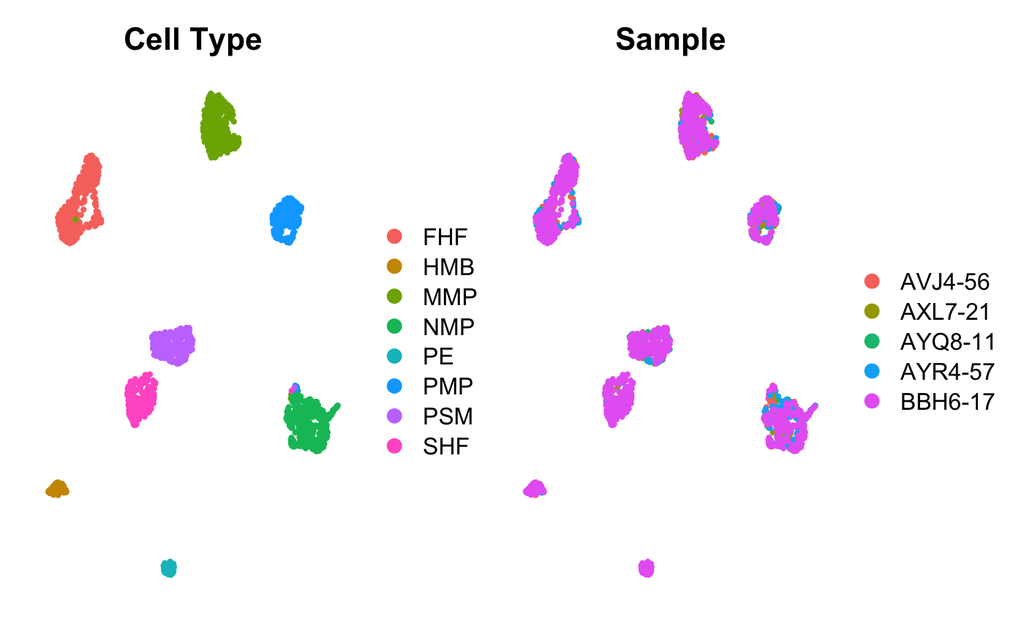

```r
p1 | p2
```

# Co-expression network analysis (WGCNA)

This is where we get into the meat of WGCNA. Interestingly, the tutorial suggests running WGCNA on each cell type. This is unexpected, since normally we would expect gene modules to be able to differentiate different cell types (rather than only describing one of them). We will use the option to select multiple groups, and select all cell types. **Notably, the PGC cells were completely dropped out. We may try rerunning with smaller metacells if this is an issue.**

```r
seurat <- SetDatExpr(
  seurat,
  group_name = levels(seurat@meta.data$cell.pop),
  group.by='cell.pop'
)
```

## Select soft-power threshold

See `1-WGCNA-mesoderm-scRNAseq.Rmd` for more information on WGCNA steps.

```r
# Test different soft powers:
seurat <- TestSoftPowers(
  seurat,
  setDatExpr = FALSE, # set this to FALSE since we did this above
)
```

```
pickSoftThreshold: will use block size 4443.
 pickSoftThreshold: calculating connectivity for given powers...
   ..working on genes 1 through 4443 of 10068
```

```
   ..working on genes 4444 through 8886 of 10068
```

```
   ..working on genes 8887 through 10068 of 10068
```

| Power | SFT.R.sq | slope | truncated.R.sq | mean.k. | median.k. | max.k. |
| --- | --- | --- | --- | --- | --- | --- |
| 1 | 5.22e-01 | 15.8000 | 0.822 | 5240.000 | 5.27e+03 | 5660.00 |
| 2 | 4.37e-01 | 7.3800 | 0.847 | 2790.000 | 2.80e+03 | 3230.00 |
| 3 | 2.69e-01 | 3.9800 | 0.865 | 1510.000 | 1.51e+03 | 1890.00 |
| 4 | 4.45e-02 | 1.3000 | 0.908 | 830.000 | 8.28e+02 | 1160.00 |
| 5 | 7.63e-06 | -0.0143 | 0.970 | 464.000 | 4.60e+02 | 732.00 |
| 6 | 3.75e-02 | -0.8590 | 0.992 | 264.000 | 2.59e+02 | 472.00 |
| 7 | 1.31e-01 | -1.3600 | 0.984 | 153.000 | 1.47e+02 | 314.00 |
| 8 | 3.24e-01 | -1.8700 | 0.957 | 90.100 | 8.43e+01 | 218.00 |
| 9 | 5.81e-01 | -2.3800 | 0.958 | 54.100 | 4.88e+01 | 156.00 |
| 10 | 7.62e-01 | -2.5500 | 0.974 | 33.100 | 2.85e+01 | 116.00 |

[output cut: 10 more lines]

```r
# plot the results:
plot_list <- PlotSoftPowers(seurat)
```

|  | Power | SFT.R.sq | slope | truncated.R.sq | mean.k. | median.k. | max.k. |
| --- | --- | --- | --- | --- | --- | --- | --- |
| 1 | 1 | 5.215782e-01 | 15.77619234 | 0.8217982 | 5242.8245 | 5273.2100 | 5656.3383 |
| 2 | 2 | 4.373478e-01 | 7.38381778 | 0.8467781 | 2785.7180 | 2804.9622 | 3234.1258 |
| 3 | 3 | 2.692164e-01 | 3.97546954 | 0.8652128 | 1507.3462 | 1512.3057 | 1894.6763 |
| 4 | 4 | 4.452906e-02 | 1.29544179 | 0.9084518 | 829.7400 | 827.6365 | 1161.3118 |
| 5 | 5 | 7.631344e-06 | -0.01433926 | 0.9703065 | 464.4301 | 459.8997 | 731.9978 |
| 6 | 6 | 3.748315e-02 | -0.85866604 | 0.9917096 | 264.3214 | 258.5118 | 472.4341 |

```
[1] "return"
```

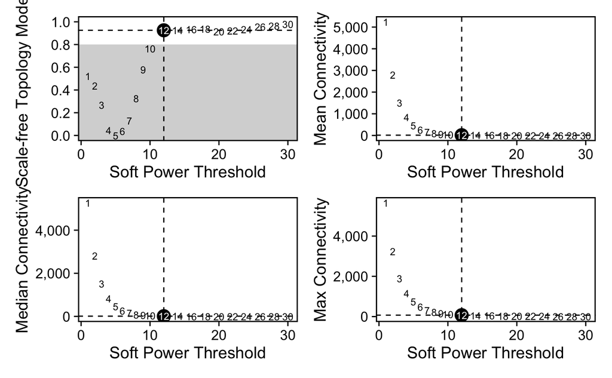

```r
# assemble with patchwork
wrap_plots(plot_list, ncol=2)
```

```r
softpower <- 12
# construct co-expression network:
seurat_obj <- ConstructNetwork(
  seurat, soft_power=softpower,
  setDatExpr=FALSE,
  tom_name = 'ALL_run_1', # name of the topological overlap matrix written to disk,
)
```

```
 Calculating consensus modules and module eigengenes block-wise from all genes
 Calculating topological overlaps block-wise from all genes
   Flagging genes and samples with too many missing values...
    ..step 1
    TOM calculation: adjacency..
    ..will not use multithreading.
     Fraction of slow calculations: 0.000000
    ..connectivity..
    ..matrix multiplication (system BLAS)..
    ..normalization..
    ..done.
 ..Working on block 1 .
 ..Working on block 1 .
 ..merging consensus modules that are too close..
```

## Module Eigengenes

hdWGCNA includes a function `ModuleEigengenes` to compute module eigengenes in single cells. Additionally, we allow the user to apply Harmony batch correction to the MEs, yielding harmonized module eigengenes (hMEs). The following code performs the module eigengene computation harmonizing by the Sample of origin using the group.by.vars parameter.

```r
# need to run ScaleData first or else harmony throws an error:
seurat <- ScaleData(seurat, features=VariableFeatures(seurat))

# compute all MEs in the full single-cell dataset
seurat <- ModuleEigengenes(
 seurat,
 group.by.vars="embryo"
)

# harmonized module eigengenes:
hMEs <- GetMEs(seurat)

# module eigengenes:
MEs <- GetMEs(seurat, harmonized=FALSE)
```

## Module connectivity

In co-expression network analysis, we often want to focus on the “hub genes”, those which are highly connected within each module. Therefore we wish to determine the eigengene-based connectivity, also known as kME, of each gene. hdWGCNA includes the ModuleConnectivity to compute the kME values in the full single-cell dataset, rather than the metacell dataset. This function essentially computes pairwise correlations between genes and module eigengenes. The tutorial recommends that kME be computed in the cell type or group that was previously used to run ConstructNetwork. Since we used all cell types, we will calculate kMEs without defining which cell type subset to use.

```r
# compute eigengene-based connectivity (kME):
seurat <- ModuleConnectivity(
  seurat)
# plot genes ranked by kME for each module
p <- PlotKMEs(seurat, ncol=5)
```

```
[1] "greenyellow"
[1] "blue"
[1] "turquoise"
[1] "pink"
[1] "midnightblue"
[1] "yellow"
[1] "tan"
[1] "red"
[1] "brown"
[1] "black"
[1] "magenta"
[1] "green"
[1] "lightcyan"
[1] "purple"
[1] "cyan"
```

[output cut: 17 more lines]

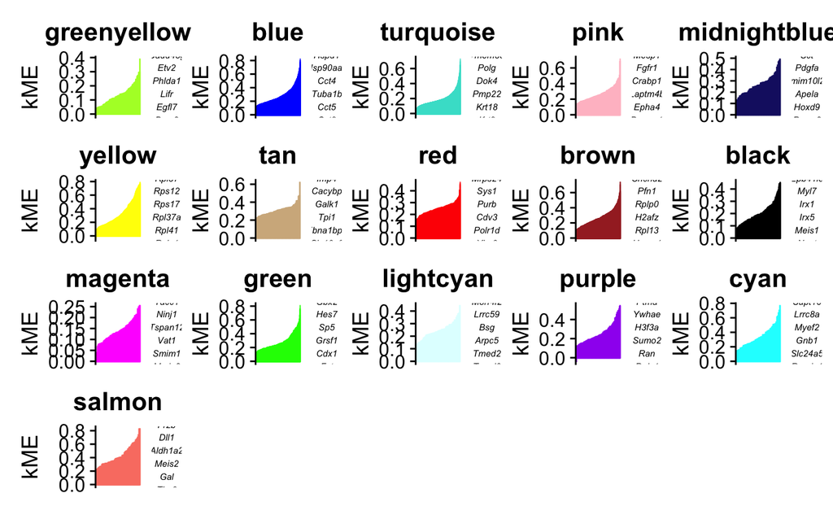

```r
p
```

```r
# get hub genes
hub_df <- GetHubGenes(seurat, n_hubs = 10)

head(hub_df)
```

|  | gene_name | module | kME |
| --- | --- | --- | --- |
| 1 | Kdr | greenyellow | 0.2199212 |
| 2 | Ddah2 | greenyellow | 0.2263451 |
| 3 | Gadd45g | greenyellow | 0.2434114 |
| 4 | Etv2 | greenyellow | 0.2452192 |
| 5 | Phlda1 | greenyellow | 0.2625641 |
| 6 | Lifr | greenyellow | 0.2700419 |

```r
saveRDS(seurat, file='seurat_mesoderm.rds')
```

## Plotting module features

```r
# need to run ScaleData first or else harmony throws an error:
seurat <- ScaleData(seurat, features=VariableFeatures(seurat))
# compute all MEs in the full single-cell dataset
seurat <- ModuleEigengenes(
 seurat,
 group.by.vars="embryo"
)
```

```
[1] "greenyellow"
```

[output not shown]

```
[1] "blue"
```

[output not shown]

```
[1] "grey"
```

[output not shown]

```
[1] "turquoise"
```

[output not shown]

```
[1] "pink"
```

[output not shown]

```
[1] "midnightblue"
```

[output not shown]

```
[1] "yellow"
```

[output not shown]

```
[1] "tan"
```

[output not shown]

```
[1] "red"
```

[output not shown]

```
[1] "brown"
```

[output not shown]

```
[1] "black"
```

[output not shown]

```
[1] "magenta"
```

[output not shown]

```
[1] "green"
```

[output not shown]

```
[1] "lightcyan"
```

[output not shown]

```
[1] "purple"
```

[output not shown]

```
[1] "cyan"
```

[output not shown]

```
[1] "salmon"
```

[output not shown]

```r
# harmonized module eigengenes:
hMEs <- GetMEs(seurat)

# module eigengenes:
MEs <- GetMEs(seurat, harmonized=FALSE)
```

```r
# make a featureplot of hMEs for each module
plot_list <- ModuleFeaturePlot(
  seurat,
  features='hMEs', # plot the hMEs
  order=TRUE # order so the points with highest hMEs are on top
)
```

[output not shown]